# Advanced Analytics to Improve Sales at Turtle Games

## Load Packages

```r
# Load necessary packages
suppressMessages(library(dplyr))
library(ggplot2)
suppressMessages(library(corrplot))
library(moments)
```

## Functions

### Descriptive Statistics

This function returns measures of central tendency, variability, shape, and normality for the specified variable.

```r
descriptive_stats <- function(x){
  # Calculate mean, median, and mode
  mean_score <- mean(x)
  median_score <- median(x)
  mode_score <- as.numeric(names(sort(table(x), decreasing = TRUE)[1]))

  # Calculate Range
  range_satisfaction <- range(x)

  # Calculate Difference between highest and lowest values
  difference_high_low <- diff(range_satisfaction)

  # Calculate Interquartile Range (IQR)
  iqr_satisfaction <- IQR(x)

  # Calculate Variance
  variance_satisfaction <- var(x)

  # Calculate Standard Deviation
  std_deviation_satisfaction <- sd(x)

  # Skewness and Kurtosis
  skewness_score = skewness(x)
  kurtosis_score = kurtosis(x)

  # Shapiro-Wilk test for normality
  shapiro_score = shapiro.test(x)
  shapiro_p <- shapiro_score$p.value

  # Print the results
  cat("MEASURES OF CENTRAL TENDENCY", "\n")
  cat("Mean:", mean_score, "\n")
  cat("Median:", median_score, "\n")
  cat("Mode:", mode_score, "\n")
  cat("\n")
  cat("MEASURES OF VARIABILITY", "\n")
  cat("Range:", range_satisfaction, "\n")
  cat("Difference:", difference_high_low, "\n")
  cat("IQR:", iqr_satisfaction, "\n")
  cat("Variance:", variance_satisfaction, "\n")
  cat("Standard Deviation:", std_deviation_satisfaction, "\n")
  cat("\n")
  cat("MEASURES OF SHAPE", "\n")
  cat("Skewness:", skewness_score, "\n")
  cat("Kurtosis:", kurtosis_score, "\n")
  cat("\n")
  cat("MEASURES OF NORMALITY", "\n")
  cat("Shapiro-Wilk p-value:", formatC(shapiro_p, format = "e", digits = 2))
}
```

## Data Import

```r
# Import turtle_rviews.csv into dataframe
df <- read.csv("turtle_reviews.csv")
```

## Data Viewing and Validation

```r
# View head of dataframe
head(df)
```

```
##   gender age remuneration..k.. spending_score..1.100. loyalty_points education
## 1   Male  18             12.30                     39            210  graduate
## 2   Male  23             12.30                     81            524  graduate
## 3 Female  22             13.12                      6             40  graduate
## 4 Female  25             13.12                     77            562  graduate
## 5 Female  33             13.94                     40            366  graduate
## 6 Female  24             13.94                     76            573       PhD
##   language platform product
## 1       EN      Web     453
## 2       EN      Web     466
## 3       EN      Web     254
## 4       EN      Web     263
## 5       EN      Web     291
## 6       EN      Web     977
##                                                                                                                                                                                                                                                                                                          …
## 1                                                                                                                                                                                                                                                                                                        …
## 2                                                                                                                                                                                                                                                                                                        …
## 3 Nice art, nice printing.  Why two panels are filled with a general Forgotten Realms map is beyond me.  Most of one of them is all blue ocean.  Such a waste.\n\nI don't understand why they can't make these DM Screens more useful for these "kinds of adventures" rather than solely the specific adv…
## 4                                                                                                                                                                                                                                                                                                        …
## 5                                                                                                                                                                                                                                                                                                        …
## 6                                                                                                                                                                                                                                                                                                        …
##                                                                                            summary
## 1 The fact that 50% of this space is wasted on art (and not terribly informative or needed art ...
## 2                                        Another worthless Dungeon Master's screen from GaleForce9
## 3                                                                  pretty, but also pretty useless
## 4                                                                                       Five Stars
## 5                                                                                       Money trap
## 6                                                                                       Five Stars
```

```r
# View the structure of the dataframe
str(df)
```

```
## 'data.frame':    2000 obs. of  11 variables:
##  $ gender                : chr  "Male" "Male" "Female" "Female" ...
##  $ age                   : int  18 23 22 25 33 24 37 25 66 32 ...
##  $ remuneration..k..     : num  12.3 12.3 13.1 13.1 13.9 ...
##  $ spending_score..1.100.: int  39 81 6 77 40 76 6 94 3 72 ...
##  $ loyalty_points        : int  210 524 40 562 366 573 61 772 31 724 ...
##  $ education             : chr  "graduate" "graduate" "graduate" "graduate" ...
##  $ language              : chr  "EN" "EN" "EN" "EN" ...
##  $ platform              : chr  "Web" "Web" "Web" "Web" ...
##  $ product               : int  453 466 254 263 291 977 979 1012 1031 1459 ...
##  $ review                : chr  "When it comes to a DM's screen, the space on the screen itself is at an absolute premium. The fact that 50% of "| __truncated__ "An Open Letter to GaleForce9*:\n\nYour unpainted miniatures are very not bad. Your spell cards are great. Your "| __truncated__ "Nice a…
##  $ summary               : chr  "The fact that 50% of this space is wasted on art (and not terribly informative or needed art ..." "Another worthless Dungeon Master's screen from GaleForce9" "pretty, but also pretty useless" "Five Stars" ...
```

**“remuneration…” and “spending_score…” column names should be changed.**

```r
# Search for missing values
sum(is.na(df))
```

```
## [1] 0
```

**There are no missing values.**

```r
# Check for unique values
sapply(df, function(x) n_distinct(x))
```

```
##                 gender                    age      remuneration..k..
##                      2                     45                     64
## spending_score..1.100.         loyalty_points              education
##                     84                    627                      5
##               language               platform                product
##                      1                      1                    200
##                 review                summary
##                   1980                   1432
```

**Two columns (“language” and “platform”) have only one unique value so they can be removed.**

```r
# Check for duplicate rows
nrow(df[duplicated(df), ])
```

```
## [1] 0
```

**There are no duplicate rows in the dataframe.**

```r
#View summary of dataframe
summary(df)
```

```
##     gender               age        remuneration..k.. spending_score..1.100.
##  Length:2000        Min.   :17.00   Min.   : 12.30    Min.   : 1
##  Class :character   1st Qu.:29.00   1st Qu.: 30.34    1st Qu.:32
##  Mode  :character   Median :38.00   Median : 47.15    Median :50
##                     Mean   :39.49   Mean   : 48.08    Mean   :50
##                     3rd Qu.:49.00   3rd Qu.: 63.96    3rd Qu.:73
##                     Max.   :72.00   Max.   :112.34    Max.   :99
##  loyalty_points  education           language           platform
##  Min.   :  25   Length:2000        Length:2000        Length:2000
##  1st Qu.: 772   Class :character   Class :character   Class :character
##  Median :1276   Mode  :character   Mode  :character   Mode  :character
##  Mean   :1578
##  3rd Qu.:1751
##  Max.   :6847
##     product         review            summary
##  Min.   :  107   Length:2000        Length:2000
##  1st Qu.: 1589   Class :character   Class :character
##  Median : 3624   Mode  :character   Mode  :character
##  Mean   : 4321
##  3rd Qu.: 6654
##  Max.   :11086
```

**The range of age values, remuneration (income) values, and spending score values make sense.**

## Data Cleaning and Transformation

```r
# Create a new dataframe with fewer, renamed, and changed-type columns
clean_df <- data.frame(
  gender = df$gender,
  age = df$age,
  income = df$remuneration..k..,
  spending_score = df$spending_score..1.100.,
  loyalty_points = df$loyalty_points,
  education = df$education,
  product = as.character(df$product),
  review = df$review,
  summary = df$summary
)

head(clean_df)
```

```
##   gender age income spending_score loyalty_points education product
## 1   Male  18  12.30             39            210  graduate     453
## 2   Male  23  12.30             81            524  graduate     466
## 3 Female  22  13.12              6             40  graduate     254
## 4 Female  25  13.12             77            562  graduate     263
## 5 Female  33  13.94             40            366  graduate     291
## 6 Female  24  13.94             76            573       PhD     977
##                                                                                                                                                                                                                                                                                                          …
## 1                                                                                                                                                                                                                                                                                                        …
## 2                                                                                                                                                                                                                                                                                                        …
## 3 Nice art, nice printing.  Why two panels are filled with a general Forgotten Realms map is beyond me.  Most of one of them is all blue ocean.  Such a waste.\n\nI don't understand why they can't make these DM Screens more useful for these "kinds of adventures" rather than solely the specific adv…
## 4                                                                                                                                                                                                                                                                                                        …
## 5                                                                                                                                                                                                                                                                                                        …
## 6                                                                                                                                                                                                                                                                                                        …
##                                                                                            summary
## 1 The fact that 50% of this space is wasted on art (and not terribly informative or needed art ...
## 2                                        Another worthless Dungeon Master's screen from GaleForce9
## 3                                                                  pretty, but also pretty useless
## 4                                                                                       Five Stars
## 5                                                                                       Money trap
## 6                                                                                       Five Stars
```

**Removed “language” and “platform” columns. The “renumeration…” column is now “income” and the extra characters in the “spending_score…” column have been removed. Changed “product” column from numeric type to character type.**

## Data Exploration

### Gender

```r
# Frequency table for the 'gender' column
gender_freq <- table(clean_df$gender)
print(gender_freq)
```

```
##
## Female   Male
##   1120    880
```

**There are slightly more female customers than male customers.**

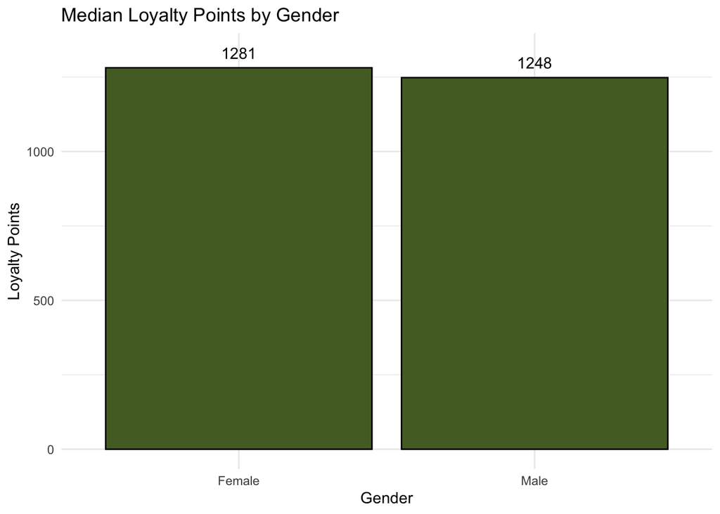

```r
# Create a bar plot for average 'loyalty_points' by 'gender'
clean_df %>%
  group_by(gender) %>%
  summarize(m = median(loyalty_points)) %>%
  ggplot(aes(x = gender, y = m)) +
    geom_bar(stat = "identity", fill = "darkolivegreen", color = "black") +
    labs(title = "Median Loyalty Points by Gender", x = "Gender", y = "Loyalty Points") +
    geom_text(aes(label = m), nudge_y = 50) +
    theme_minimal()
```

**On average, female and male customers accumulate similar amounts of loyalty points**

### Education

```r
# Frequency table for the 'education' column
ed_freq <- table(clean_df$education)
print(ed_freq)
```

```
##
##        Basic      diploma     graduate          PhD postgraduate
##           50          190          900          460          400
```

**The overwhelming majority of customers have a university education.**

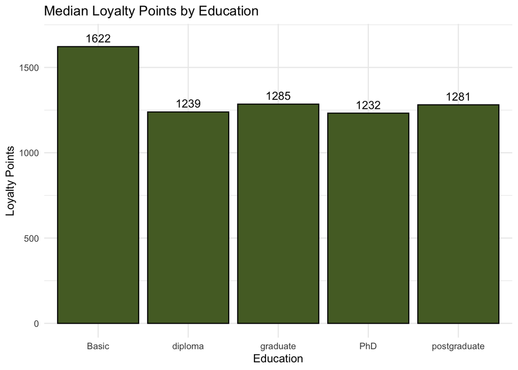

```r
# Create a bar plot for average 'loyalty_points' by 'education'
clean_df %>%
  group_by(education) %>%
  summarize(m = median(loyalty_points)) %>%
  ggplot(aes(x = education, y = m)) +
    geom_bar(stat = "identity", fill = "darkolivegreen", color = "black") +
    labs(title = "Median Loyalty Points by Education", x = "Education", y = "Loyalty Points") +
    geom_text(aes(label = m), nudge_y = 50) +
    theme_minimal()
```

**On average, customers with a basic education accumulate more loyalty points than customers with higher levels of education.**

### Age

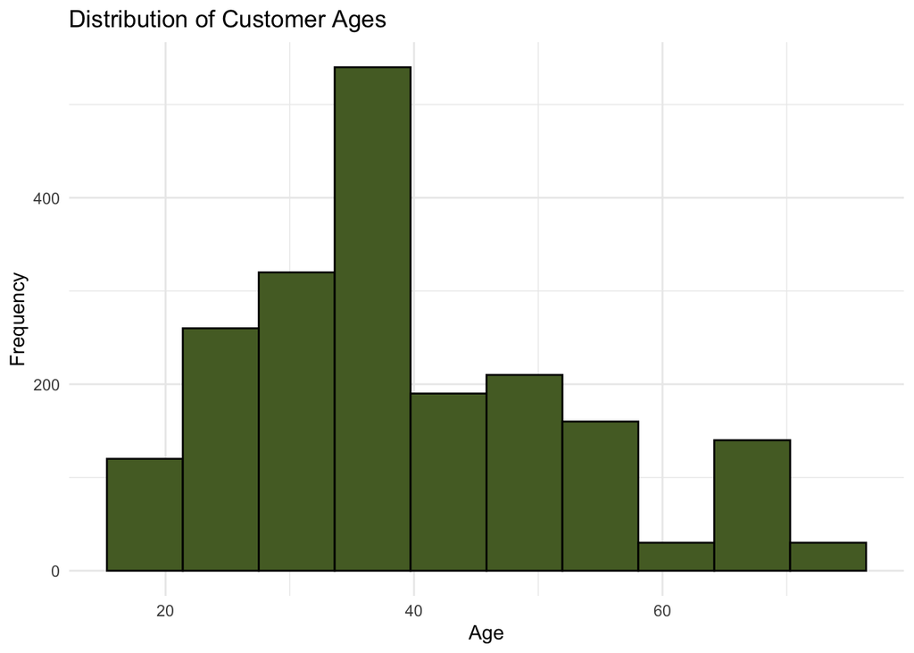

```r
# Create a histogram for 'age'
plot <- ggplot(data = clean_df, aes(x = age)) +
  geom_histogram(bins = 10, fill = "darkolivegreen", color = "black") +
  labs(title = "Distribution of Customer Ages", x = "Age", y = "Frequency") +
  theme_minimal()

plot
```

**The historgram is right skewed, which means that the majority of customers tend to be younger (17-40 years old).**

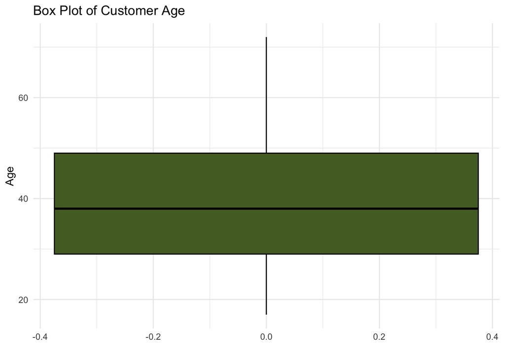

```r
# Create a box plot for 'age'
ggplot(data = clean_df, aes(y = age)) +
  geom_boxplot(fill = "darkolivegreen", color = "black") +
  labs(title = "Box Plot of Customer Age", y = "Age", x = "") +
  theme_minimal()
```

**There are no age outliers.**

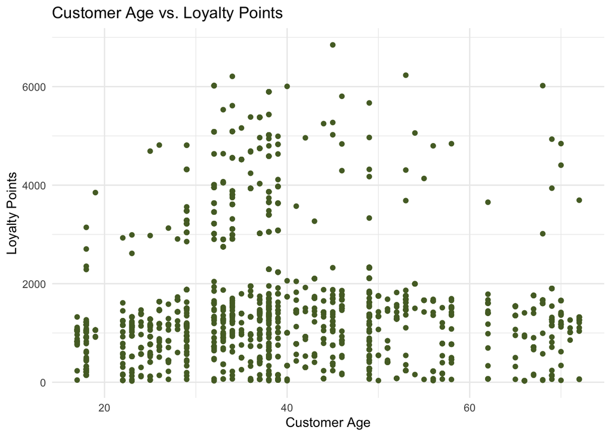

```r
# Create a scatter plot for 'age' vs 'loyalty_points'
ggplot(data = clean_df, aes(x = age, y = loyalty_points)) +
  geom_point(color = "darkolivegreen") +
  labs(title = "Customer Age vs. Loyalty Points", x = "Customer Age", y = "Loyalty Points") +
  theme_minimal()
```

**There’s an interesting horizontal gap in the plot around 2000 loyalty points that gradually increases with age until about the age of 50. There’s not much of a pattern below the gap but above it there appears to be a very slight positive linear relationship between age and loyalty points.**

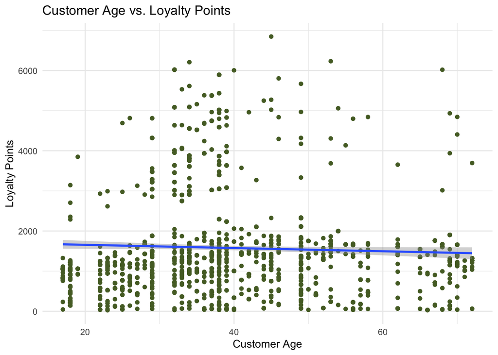

```r
# Create a trend line for 'age' vs 'loyalty_points'
ggplot(data = clean_df, aes(x = age, y = loyalty_points)) +
  geom_point(color = "darkolivegreen") +
  geom_smooth(method=lm) +
  labs(title = "Customer Age vs. Loyalty Points", x = "Customer Age", y = "Loyalty Points") +
  theme_minimal()
```

**The trend line for the scatter plot as a whole is nearly horizontal, which suggests there is very little correlation between age and loyalty points.**

### Income

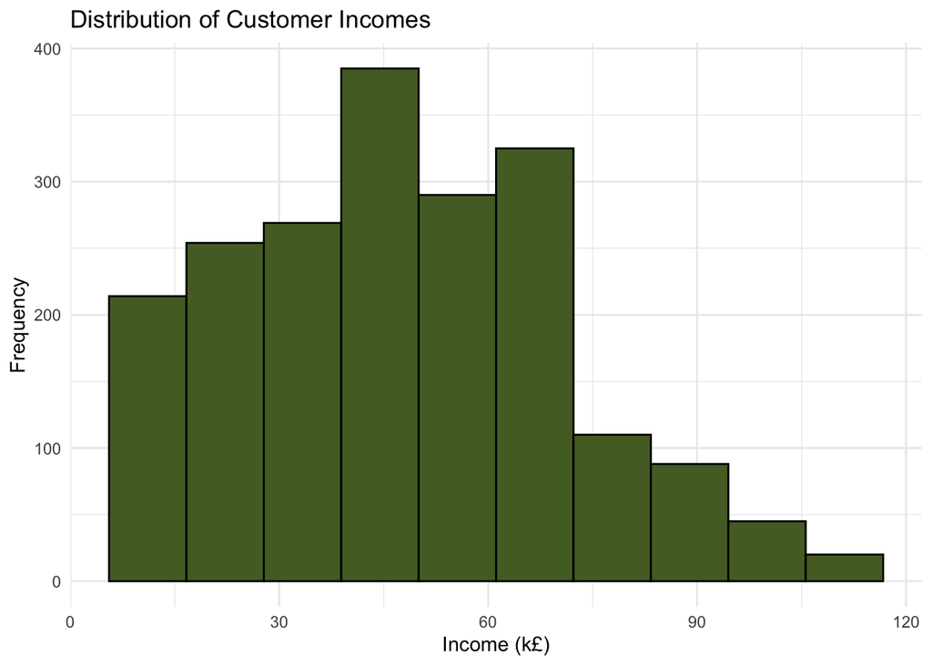

```r
# Create a histogram for 'income'
plot <- ggplot(data = clean_df, aes(x = income)) +
  geom_histogram(bins = 10, fill = "darkolivegreen", color = "black") +
  labs(title = "Distribution of Customer Incomes", x = "Income (k£)", y = "Frequency") +
  theme_minimal()

plot
```

**The histogram is right skewed, which means that most customers tend to have incomes under £70k.**

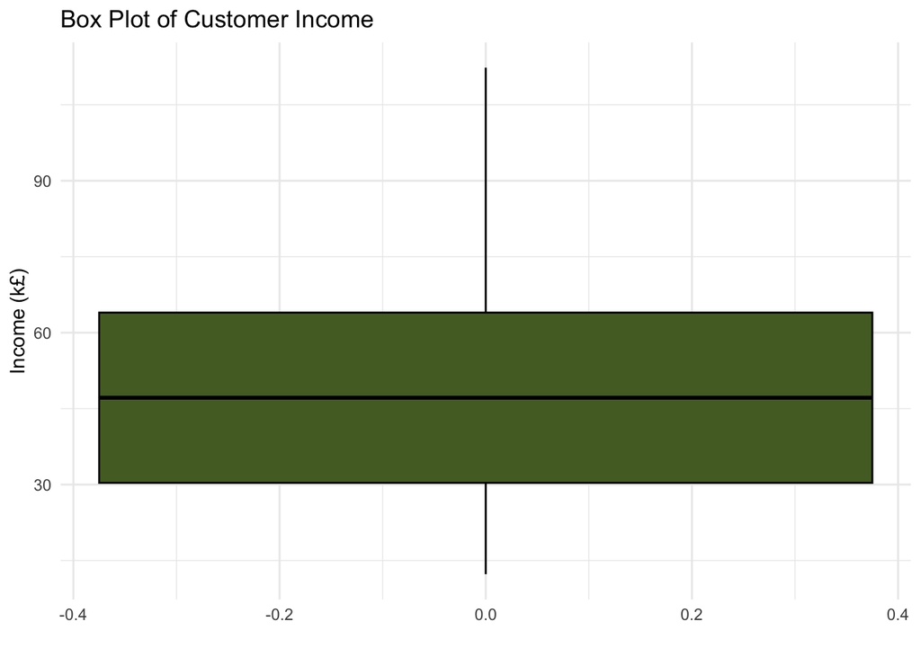

```r
# Create a box plot for 'income'
ggplot(data = clean_df, aes(y = income)) +
  geom_boxplot(fill = "darkolivegreen", color = "black") +
  labs(title = "Box Plot of Customer Income", y = "Income (k£)", x = "") +
  theme_minimal()
```

**There are no income outliers.**

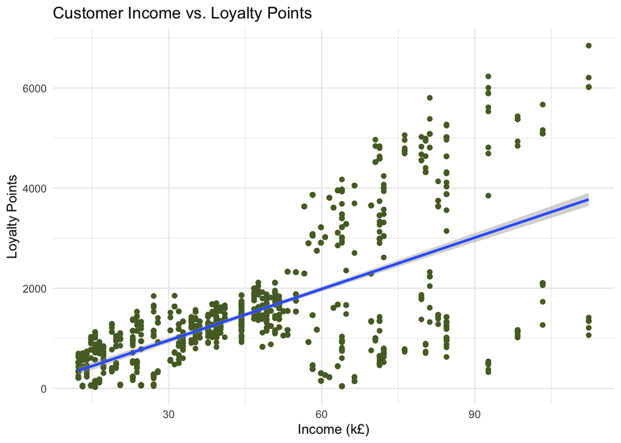

```r
# Create a trend line for 'income' vs 'loyalty_points'
ggplot(data = clean_df, aes(x = income, y = loyalty_points)) +
  geom_point(color = "darkolivegreen") +
  geom_smooth(method=lm) +
  labs(title = "Customer Income vs. Loyalty Points", x = "Income (k£)", y = "Loyalty Points") +
  theme_minimal()
```

**There is a positive linear relationship between income and loyalty points, especially for incomes below £60k. There is a wider range of loyalty point values for incomes above £60k (the residuals get longer as income increases beyond £60k).**

### Spending Score

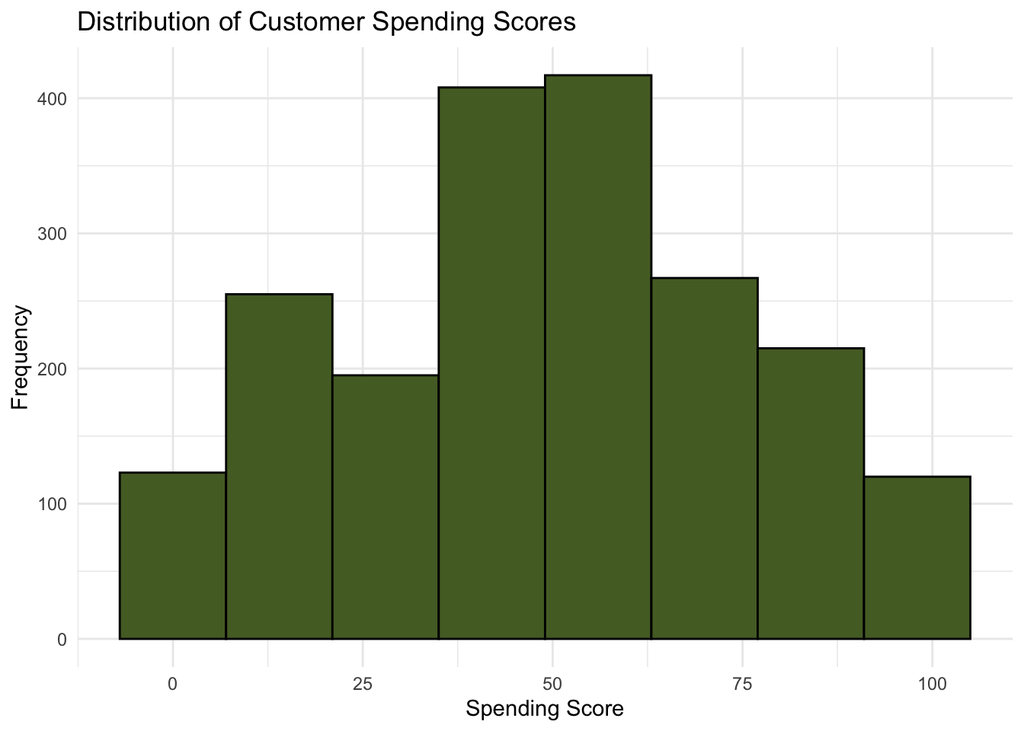

```r
# Create a histogram for 'spending_score'
plot <- ggplot(data = clean_df, aes(x = spending_score)) +
  geom_histogram(bins = 8, fill = "darkolivegreen", color = "black") +
  labs(title = "Distribution of Customer Spending Scores", x = "Spending Score", y = "Frequency") +
  theme_minimal()

plot
```

**This histogram has a fairly normal distribution centred around 50 which is not surprising because this is a score assigned to customers by Turtle Games.**

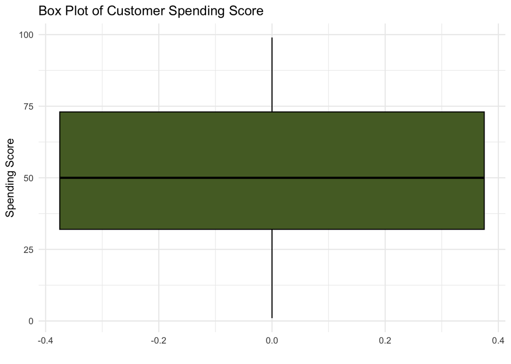

```r
# Create a box plot for 'spending_score'
ggplot(data = clean_df, aes(y = spending_score)) +
  geom_boxplot(fill = "darkolivegreen", color = "black") +
  labs(title = "Box Plot of Customer Spending Score", y = "Spending Score", x = "") +
  theme_minimal()
```

**There are no spending score outliers**

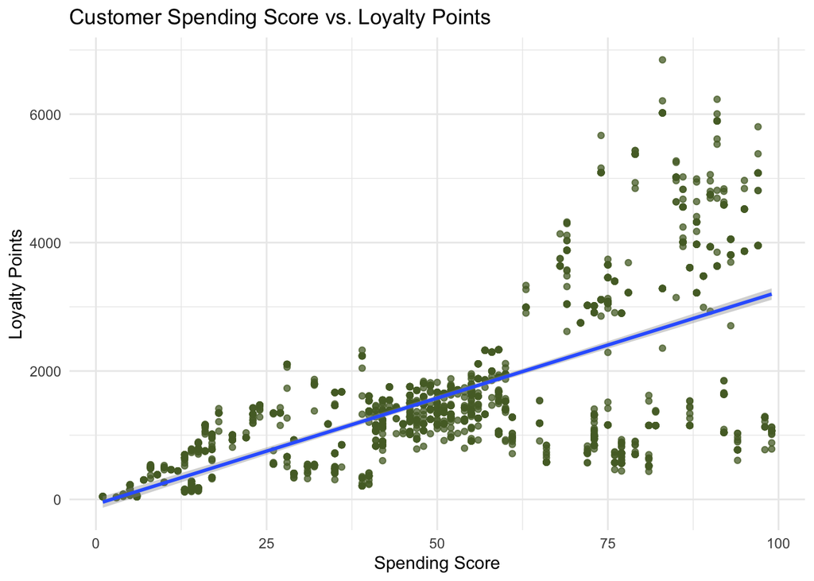

```r
# Create a trend line for 'spending_score' vs 'loyalty_points'
ggplot(data = clean_df, aes(x = spending_score, y = loyalty_points)) +
  geom_point(color = "darkolivegreen", alpha = .75) +
  geom_smooth(method=lm) +
  labs(title = "Customer Spending Score vs. Loyalty Points", x = "Spending Score", y = "Loyalty Points") +
  theme_minimal()
```

**There is a positive linear relationship between spending score and loyalty points, especially for spending scores below £60k. There is a wider range of loyalty point values for spending scores above 60 (the residuals tend to get longer as spending score increases beyond 60).**

### Loyalty Points

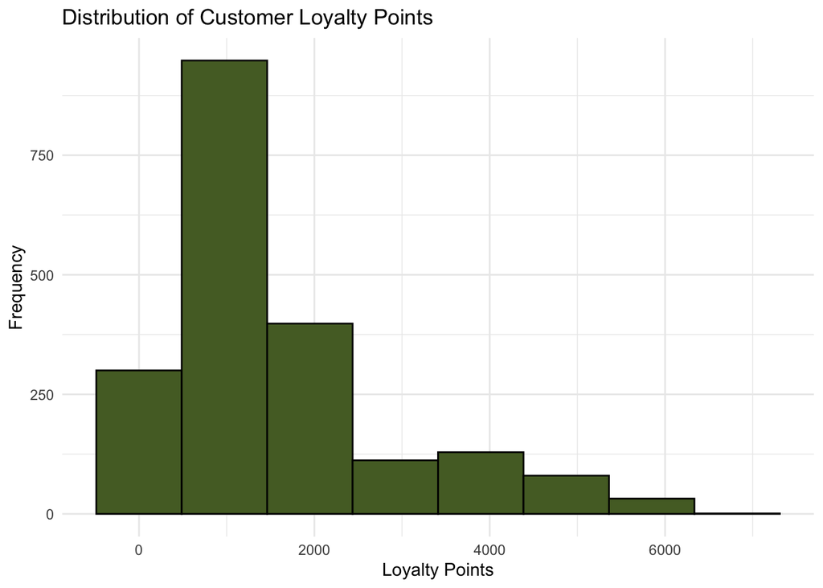

```r
# Create a histogram for 'loyalty_points'
plot <- ggplot(data = clean_df, aes(x = loyalty_points)) +
  geom_histogram(bins = 8, fill = "darkolivegreen", color = "black") +
  labs(title = "Distribution of Customer Loyalty Points", x = "Loyalty Points", y = "Frequency") +
  theme_minimal()

plot
```

**The historgram is right skewed, which means that the majority of customers have less than approximately 2,500 loyalty points.**

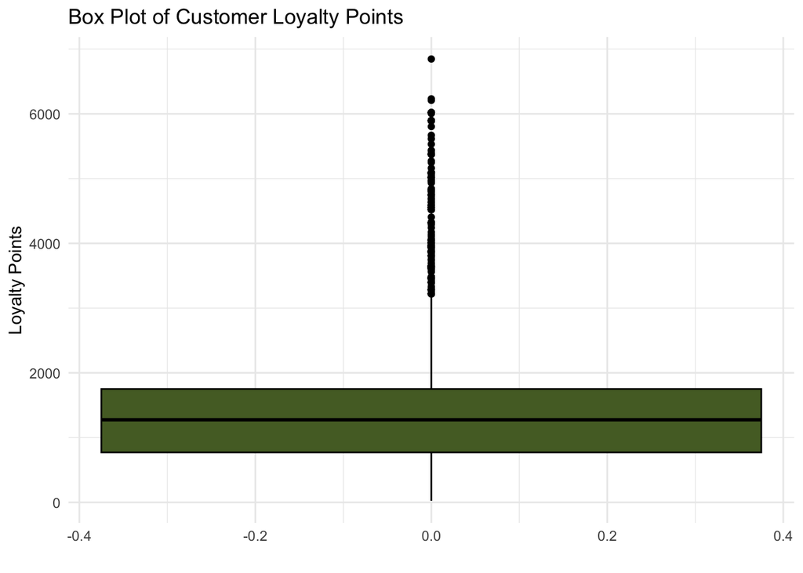

```r
# Create a box plot for 'loyalty_points'
ggplot(data = clean_df, aes(y = loyalty_points)) +
  geom_boxplot(fill = "darkolivegreen", color = "black") +
  labs(title = "Box Plot of Customer Loyalty Points", y = "Loyalty Points", x = "") +
  theme_minimal()
```

**The loyalty points box plot has several outliers on the upper end because a number of customers have earned a lot of loyalty points. There is no reason to remove these values from the dataset.**

### Product

```r
# Create dataframe grouped by product number
product_df <- clean_df %>%
  group_by(product) %>%
  summarize(avg_lp = mean(loyalty_points), product_count = n())

summary(product_df)
```

```
##    product              avg_lp       product_count
##  Length:200         Min.   : 556.5   Min.   : 8
##  Class :character   1st Qu.:1181.3   1st Qu.:10
##  Mode  :character   Median :1420.7   Median :10
##                     Mean   :1577.4   Mean   :10
##                     3rd Qu.:1938.8   3rd Qu.:10
##                     Max.   :3340.8   Max.   :13
```

**There are 200 different product numbers and there is an average of 10 records for each product, with each product number having at least 8 records and no more than 13 records. The highest average loyalty points for a product number is 3,340.8 whereas the lowest average loyalty points for a product number is 556.5**

```r
arrange(product_df, desc(avg_lp))
```

```
## # A tibble: 200 × 3
##    product avg_lp product_count
##    <chr>    <dbl>         <int>
##  1 9080     3341.            10
##  2 8962     3173.            10
##  3 4399     3156.            10
##  4 3403     3072.            10
##  5 8923     2972.            10
##  6 6504     2927.            10
##  7 4065     2912             10
##  8 6466     2899.            10
##  9 9150     2814.            10
## 10 4415     2735.            10
## # ℹ 190 more rows
```

```r
# Filter clean_df by product number
filter(clean_df, product == "9080")
```

```
##    gender age income spending_score loyalty_points    education product
## 1  Female  45  98.40             16           1156     graduate    9080
## 2  Female  38  92.66             91           5895     graduate    9080
## 3  Female  38  92.66             91           5895     graduate    9080
## 4  Female  36  84.46             23           1328          PhD    9080
## 5  Female  53  82.82             24           1469 postgraduate    9080
## 6  Female  34  79.54             86           4555        Basic    9080
## 7  Female  32  72.16             86           4007 postgraduate    9080
## 8  Female  38  98.40             79           5434      diploma    9080
## 9  Female  32  82.82             68           3636 postgraduate    9080
## 10   Male  40  15.58              3             33          PhD    9080
##                                                                                                                                                                                                                                                                                                          …
## 1                                                                                                                                                                                                                                                                                                        …
## 2                                                                                                                                                                                                                                                                                                        …
## 3                                                                                                                                                                                                                                                                                                        …
```

[output cut: 18 more lines]

**The reviews for this product number seem to be discussing different products so I have concluded that each unique product number does not refer a unique product. This precludes me from conducting any product-specific analysis, such as whether there are specific products that high reviews with especially high or low sentiment scores.**

## Correlation Analysis

```r
# Create new dataframe with numeric columns
numeric_df <- clean_df %>%
  select_if(is.numeric)

head(numeric_df)
```

```
##   age income spending_score loyalty_points
## 1  18  12.30             39            210
## 2  23  12.30             81            524
## 3  22  13.12              6             40
## 4  25  13.12             77            562
## 5  33  13.94             40            366
## 6  24  13.94             76            573
```

**The product column is not included because I transformed it to a character/string type**

```r
# Calculate the correlation matrix
correlation_matrix <- cor(numeric_df, use = "complete.obs")

# View the correlation matrix
correlation_matrix
```

```
##                         age       income spending_score loyalty_points
## age             1.000000000 -0.005708284   -0.224334309    -0.04244465
## income         -0.005708284  1.000000000    0.005612492     0.61606475
## spending_score -0.224334309  0.005612492    1.000000000     0.67231011
## loyalty_points -0.042444647  0.616064748    0.672310112     1.00000000
```

**Both spending score and income have a strong correlation with loyalty points in comparison to age. Spending score has a slightly higher correlation coefficient than income. This is not surprising because Turtle Games has its own formulas for assigning spending scores and awarding loyalty points to its customers and one of the main objectives of loyalty programmes is to incentivise higher levels of spending.**

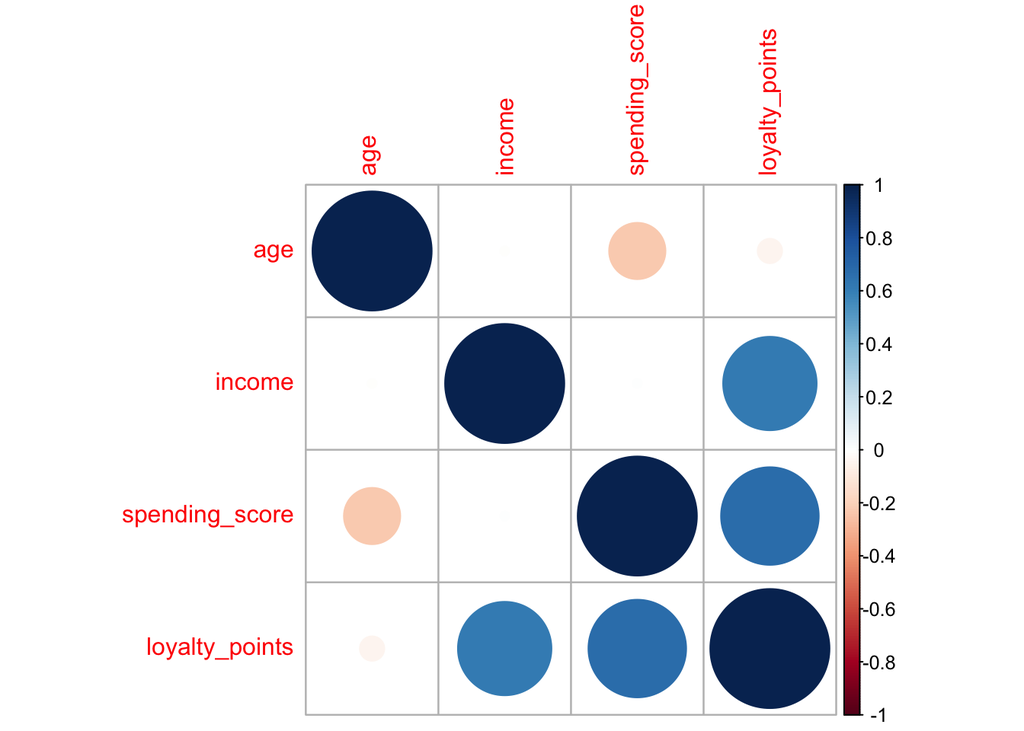

```r
# Create the correlation plot
corrplot(correlation_matrix, method = "circle")
```

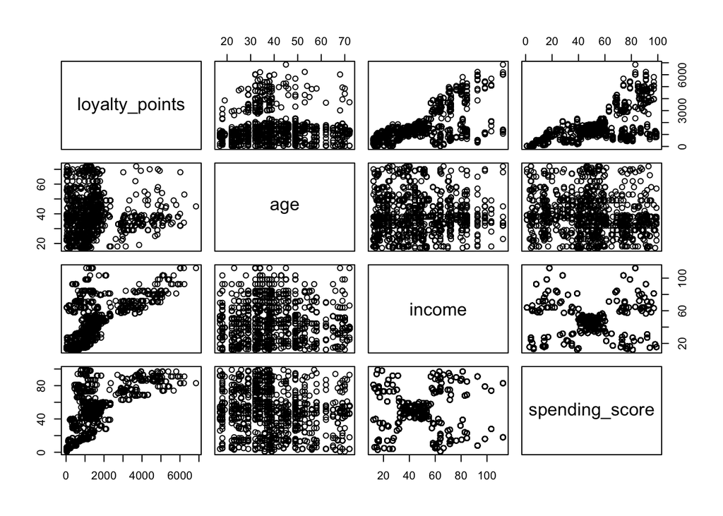

```r
# Pair plots to visualize relationships
pairs(clean_df[, c('loyalty_points', 'age', 'income', 'spending_score')])
```

## Descriptive Statistics for Loyalty Points Data

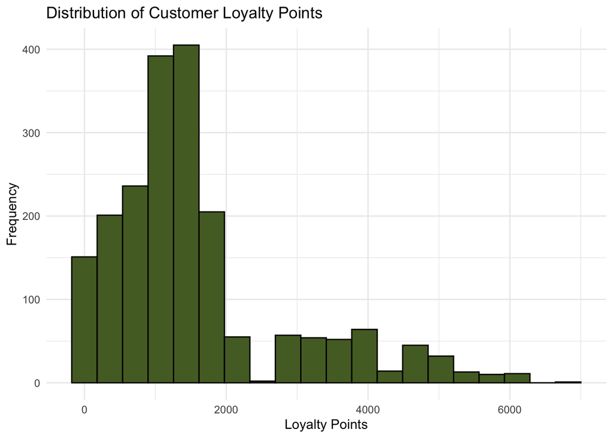

```r
# Create a histogram for 'loyalty_points'
plot <- ggplot(data = clean_df, aes(x = loyalty_points)) +
  geom_histogram(bins = 20, fill = "darkolivegreen", color = "black") +
  labs(title = "Distribution of Customer Loyalty Points", x = "Loyalty Points", y = "Frequency") +
  theme_minimal()

plot
```

```r
descriptive_stats(clean_df$loyalty_points)
```

```
## MEASURES OF CENTRAL TENDENCY
## Mean: 1578.032
## Median: 1276
## Mode: 1014
##
## MEASURES OF VARIABILITY
## Range: 25 6847
## Difference: 6822
## IQR: 979.25
## Variance: 1646704
## Standard Deviation: 1283.24
##
## MEASURES OF SHAPE
## Skewness: 1.463694
## Kurtosis: 4.70883
##
## MEASURES OF NORMALITY
## Shapiro-Wilk p-value: 1.24e-40
```

**A typical customer accumulates around 1578 loyalty points with a standard deviation of around 1283 points. The skewness score is greater than 1 so the data is asymmetrical and its distribution is not within the range of normality. The kurtosis value is also outside of the normal range and indicates the distribution plot has heavy tails and extreme values. The Shapiro-Wilk is close to zero so the loyalty points data is not normally distributed.**

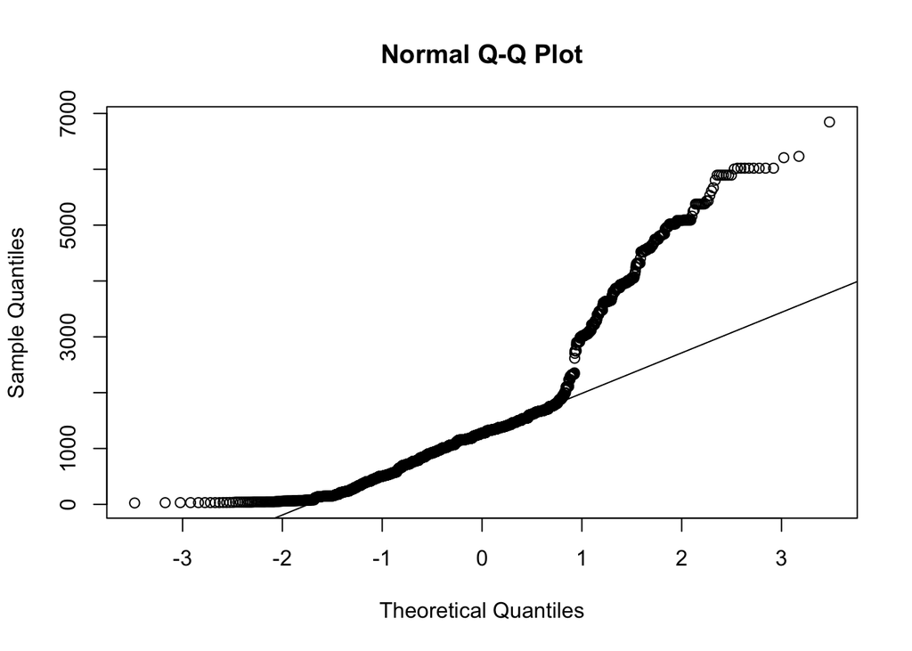

```r
qqnorm(clean_df$loyalty_points)
qqline(clean_df$loyalty_points)
```

**The qq-plot also demonstrates how the loyalty points data deviates from the line of normality.**

## Data Modeling

### Simple Linear Regression

```r
# Create a model with only one x variable.
model1 <- lm(loyalty_points ~ spending_score,
             data=clean_df)


# View the model.
model1
```

```
##
## Call:
## lm(formula = loyalty_points ~ spending_score, data = clean_df)
##
## Coefficients:
##    (Intercept)  spending_score
##         -75.05           33.06
```

```r
# View more outputs for the model - the full regression table.
summary(model1)
```

```
##
## Call:
## lm(formula = loyalty_points ~ spending_score, data = clean_df)
##
## Residuals:
##     Min      1Q  Median      3Q     Max
## -2424.7  -426.5     6.9   409.1  4177.9
##
## Coefficients:
##                Estimate Std. Error t value Pr(>|t|)
## (Intercept)    -75.0527    45.9306  -1.634    0.102
## spending_score  33.0617     0.8144  40.595   <2e-16 ***
## ---
## Signif. codes:  0 '***' 0.001 '**' 0.01 '*' 0.05 '.' 0.1 ' ' 1
##
## Residual standard error: 950.2 on 1998 degrees of freedom
## Multiple R-squared:  0.452,  Adjusted R-squared:  0.4517
## F-statistic:  1648 on 1 and 1998 DF,  p-value: < 2.2e-16
```

**The R-squared value is okay but could probably be improved with a multiple linear regression.**

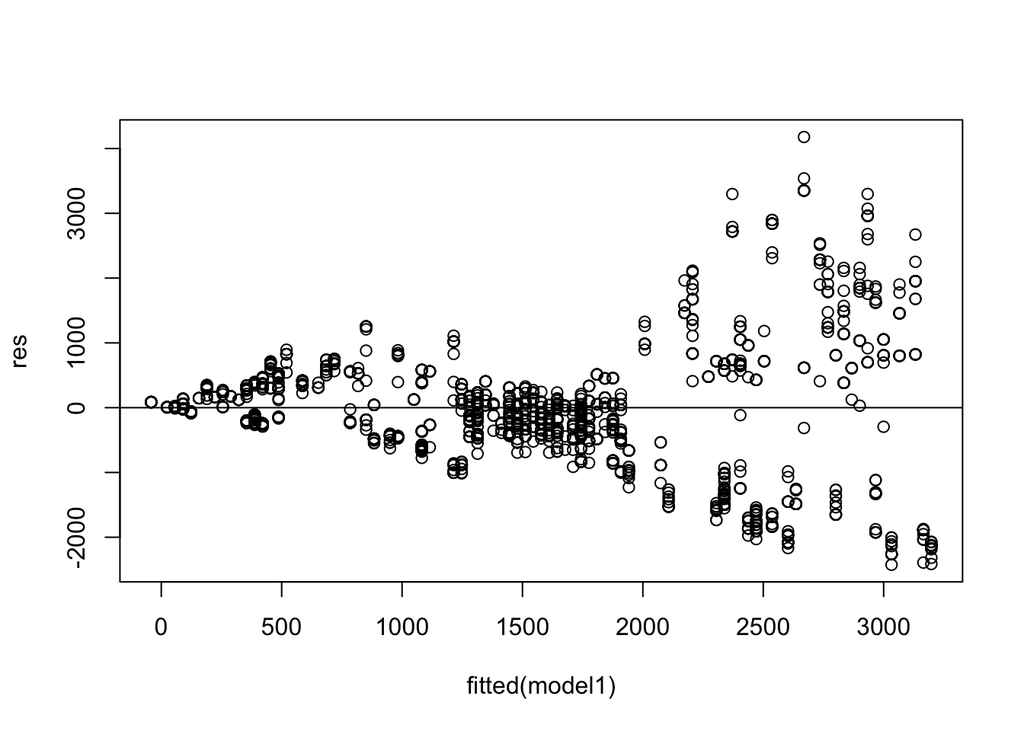

```r
# View residuals on a plot.
#get list of residuals
res <- resid(model1)

#produce residual vs. fitted plot
plot(fitted(model1), res)

#add a horizontal line at 0
abline(0,0)
```

**There residuals plot fans out on the right hand side, which violates the the assumption of homoscedasticity.**

```r
# Plot the relationship with base R graphics.
plot(clean_df$income, clean_df$loyalty_points)
coefficients(model1)
```

```
##    (Intercept) spending_score
##      -75.05266       33.06169
```

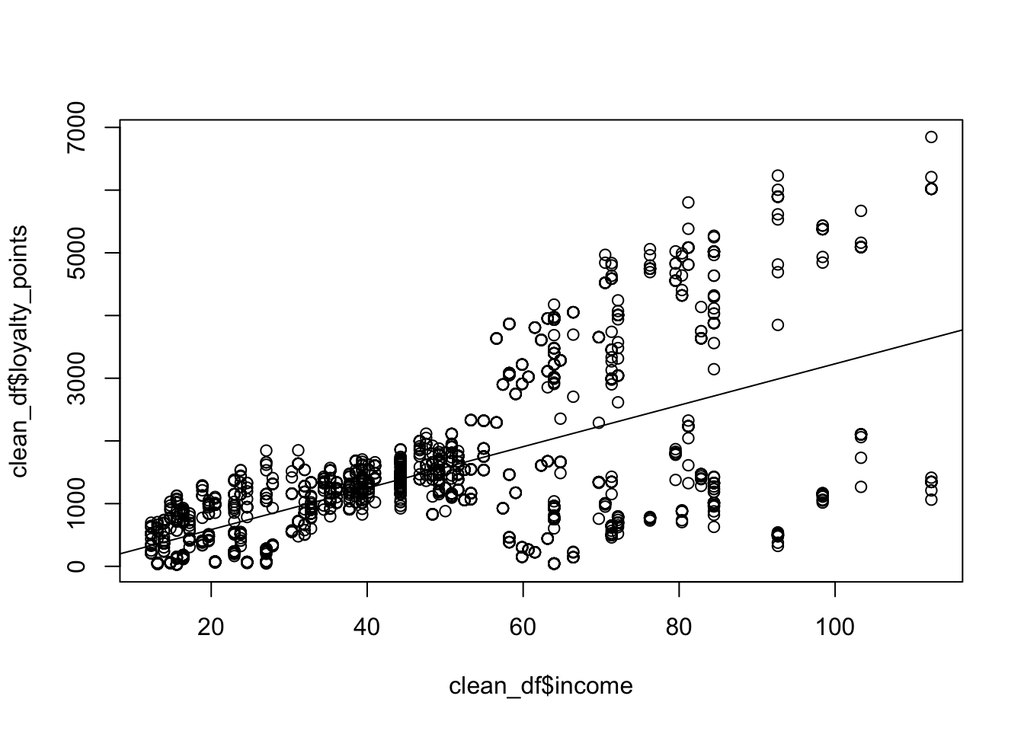

```r
# Add line-of-best-fit.
abline(coefficients(model1))
```

**The line doesn’t fit as the data points fan out around the £60k mark.**

### Multiple Linear Regression

```r
# Create the multiple linear regression model
model2 <- lm(loyalty_points ~ age + income + spending_score, data = clean_df)

# Summarize the model
summary(model2)
```

```
##
## Call:
## lm(formula = loyalty_points ~ age + income + spending_score,
##     data = clean_df)
##
## Residuals:
##      Min       1Q   Median       3Q      Max
## -1819.11  -350.84     4.61   291.00  1894.62
##
## Coefficients:
##                  Estimate Std. Error t value Pr(>|t|)
## (Intercept)    -2203.0598    52.3609  -42.08   <2e-16 ***
## age               11.0607     0.8688   12.73   <2e-16 ***
## income            34.0084     0.4970   68.43   <2e-16 ***
## spending_score    34.1832     0.4519   75.64   <2e-16 ***
## ---
## Signif. codes:  0 '***' 0.001 '**' 0.01 '*' 0.05 '.' 0.1 ' ' 1
##
## Residual standard error: 513.8 on 1996 degrees of freedom
## Multiple R-squared:  0.8399, Adjusted R-squared:  0.8397
## F-statistic:  3491 on 3 and 1996 DF,  p-value: < 2.2e-16
```

**This is a much better R-squared than that of the single linear regression model.**

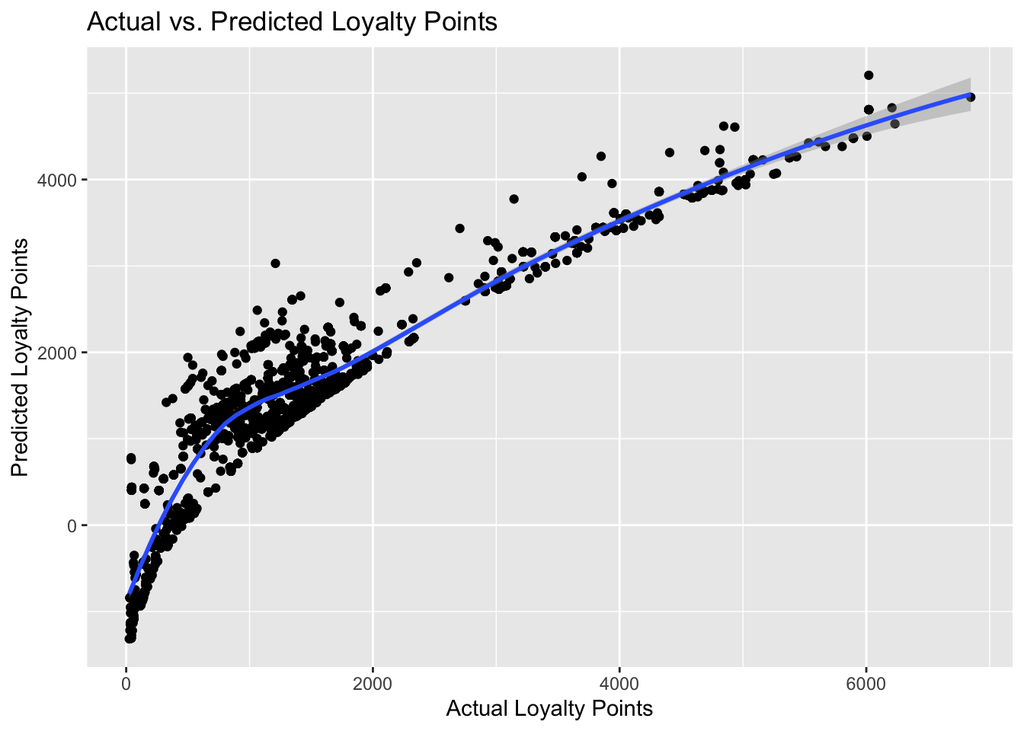

```r
# Plot actual vs. predicted values with a smoothing method
ggplot(clean_df, aes(x = loyalty_points, y = predict(model2, clean_df))) +
  geom_point() +
  stat_smooth(method = "loess") +
  labs(x = 'Actual Loyalty Points', y = 'Predicted Loyalty Points') +
  ggtitle('Actual vs. Predicted Loyalty Points')
```

**This plot suggests the model is a pretty good fit.**

Predicting with new data

Example scenarios Let’s say we have 2 new customers whose details are as follows Customer 1: age= 45, income = 60, spending_score = 25 Customer 2: age= 75, income = 20, spending_score = 50

```r
new_data <- data.frame(age = c(45, 75), income = c(60, 20), spending_score = c(25, 50))

# Predict satisfaction score for new scenarios
predictions <- predict(model2, new_data)
print(predictions)
```

```
##        1        2
## 1189.753 1015.817
```

```r
# Create the multiple linear regression model
model3 <- lm(loyalty_points ~ income + spending_score, data = clean_df)

#get list of residuals
res <- resid(model3)

# Summarize the model
summary(model3)
```

```
##
## Call:
## lm(formula = loyalty_points ~ income + spending_score, data = clean_df)
##
## Residuals:
##      Min       1Q   Median       3Q      Max
## -1646.02  -363.66    40.34   280.59  1999.95
##
## Coefficients:
##                  Estimate Std. Error t value Pr(>|t|)
## (Intercept)    -1700.3051    35.7396  -47.58   <2e-16 ***
## income            33.9795     0.5166   65.77   <2e-16 ***
## spending_score    32.8927     0.4578   71.84   <2e-16 ***
## ---
## Signif. codes:  0 '***' 0.001 '**' 0.01 '*' 0.05 '.' 0.1 ' ' 1
##
## Residual standard error: 534.1 on 1997 degrees of freedom
## Multiple R-squared:  0.8269, Adjusted R-squared:  0.8267
## F-statistic:  4770 on 2 and 1997 DF,  p-value: < 2.2e-16
```

**This is still a good model even without including age as an independent variable.**

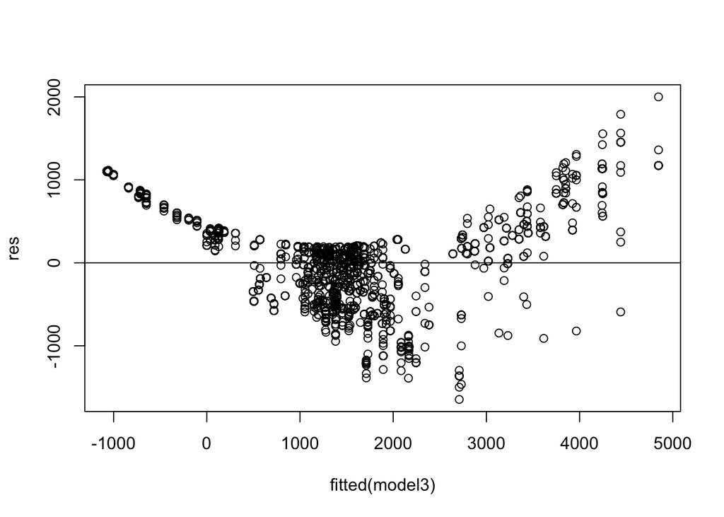

```r
#produce residual vs. fitted plot
plot(fitted(model3), res)

#add a horizontal line at 0
abline(0,0)
```

**There appears to be a pattern in the residuals plot so the assumption of homoscedasticity is not fulfilled.**

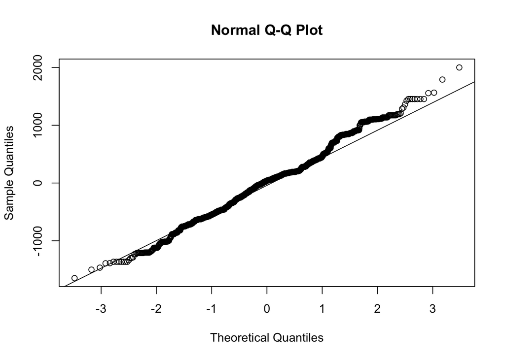

```r
qqnorm(res)
qqline(res)
```

**The data has a fairly normal distribution judging from this plot.**